# Rank-normalized split-Rhat and effective sample size

### 4.2.12 Non-centered Eight Schools model

In the following, we want to expand our understanding of the non-centered parameterization of the hierarchical model fit to the eight schools data.

```r
writeLines(readLines("eight_schools_ncp.stan"))
```

```
data {
  int<lower=0> J;
  real y[J];
  real<lower=0> sigma[J];
}

parameters {
  real mu;
  real<lower=0> tau;
  real theta_tilde[J];
}

transformed parameters {
  real theta[J];
  for (j in 1:J)
    theta[j] = mu + tau * theta_tilde[j];
}

model {
  mu ~ normal(0, 5);
  tau ~ cauchy(0, 5);
  theta_tilde ~ normal(0, 1);
  y ~ normal(theta, sigma);
}
```

#### 4.2.12.1 Non-centered parameterization with default MCMC options

In the main text, we have already seen that the non-centered parameterization works better than the centered parameterization, at least when we use an increased `adapt_delta` value. Let’s see what happens when using the default MCMC option of Stan.

```r
fit_ncp <- stan(
  file = 'eight_schools_ncp.stan', data = eight_schools,
  iter = 2000, chains = 4, seed = 483892929, refresh = 0
)
```

We observe a few divergent transitions with the default of `adapt_delta=0.8`. Let’s analyze the sample.

```r
monitor(fit_ncp)
```

```
Inference for the input samples (4 chains: each with iter = 2000; warmup = 1000):

                   Q5   Q50   Q95  Mean   SD Rhat Bulk_ESS Tail_ESS
mu              -0.98  4.41  9.52  4.38 3.24    1     4083     2378
tau              0.25  2.77  9.77  3.61 3.16    1     2303     1795
theta_tilde[1]  -1.31  0.35  1.88  0.32 0.97    1     4571     2604
theta_tilde[2]  -1.41  0.14  1.64  0.12 0.92    1     5771     3078
theta_tilde[3]  -1.62 -0.10  1.49 -0.09 0.96    1     4966     3054
theta_tilde[4]  -1.43  0.03  1.51  0.05 0.91    1     5442     2830
theta_tilde[5]  -1.67 -0.17  1.35 -0.16 0.91    1     4273     3005
theta_tilde[6]  -1.64 -0.08  1.48 -0.07 0.95    1     5192     2981
theta_tilde[7]  -1.25  0.39  1.88  0.36 0.97    1     3898     2800
theta_tilde[8]  -1.51  0.07  1.68  0.08 0.97    1     4848     2863
theta[1]        -1.38  5.68 15.84  6.27 5.60    1     3790     2549
theta[2]        -2.29  4.88 12.83  5.03 4.62    1     5002     2920
theta[3]        -4.28  4.08 11.90  3.95 5.24    1     4001     3036
theta[4]        -2.74  4.66 12.09  4.64 4.63    1     4699     3063
theta[5]        -4.13  3.89 10.45  3.63 4.54    1     4310     3184
theta[6]        -4.11  4.19 11.30  3.95 4.88    1     4965     2806
theta[7]        -0.84  5.86 15.18  6.28 4.94    1     4599     3296
theta[8]        -3.24  4.77 13.52  4.91 5.37    1     4461     3288
lp__           -11.06 -6.47 -3.68 -6.81 2.30    1     1711     2385

For each parameter, Bulk_ESS and Tail_ESS are crude measures of
effective sample size for bulk and tail quantities respectively (good values is
ESS > 400), and Rhat is the potential scale reduction factor on rank normalized
split chains (at convergence, Rhat = 1).
```

```r
res <- monitor_extra(fit_ncp)
print(res)
```

```
Inference for the input samples (4 chains: each with iter = 2000; warmup = 1000):

                mean se_mean   sd     Q5   Q50   Q95 seff reff sseff zseff zsseff zsreff Rhat sRhat
mu              4.38    0.05 3.24  -0.98  4.41  9.52 4023 1.01  4036  4070   4083   1.02    1     1
tau             3.61    0.06 3.16   0.25  2.77  9.77 2684 0.67  2700  2293   2303   0.58    1     1
theta_tilde[1]  0.32    0.01 0.97  -1.31  0.35  1.88 4528 1.13  4566  4532   4571   1.14    1     1
theta_tilde[2]  0.12    0.01 0.92  -1.41  0.14  1.64 5742 1.44  5758  5754   5771   1.44    1     1
theta_tilde[3] -0.09    0.01 0.96  -1.62 -0.10  1.49 4929 1.23  4974  4919   4966   1.24    1     1
theta_tilde[4]  0.05    0.01 0.91  -1.43  0.03  1.51 5370 1.34  5436  5376   5442   1.36    1     1
theta_tilde[5] -0.16    0.01 0.91  -1.67 -0.17  1.35 4222 1.06  4269  4226   4273   1.07    1     1
theta_tilde[6] -0.07    0.01 0.95  -1.64 -0.08  1.48 5182 1.30  5195  5179   5192   1.30    1     1
theta_tilde[7]  0.36    0.02 0.97  -1.25  0.39  1.88 3885 0.97  3888  3893   3898   0.97    1     1
theta_tilde[8]  0.08    0.01 0.97  -1.51  0.07  1.68 4838 1.21  4853  4834   4848   1.21    1     1
theta[1]        6.27    0.09 5.60  -1.38  5.68 15.84 3504 0.88  3530  3767   3790   0.95    1     1
theta[2]        5.03    0.07 4.62  -2.29  4.88 12.83 4892 1.22  4928  4965   5002   1.25    1     1
theta[3]        3.95    0.09 5.24  -4.28  4.08 11.90 3796 0.95  3825  3971   4001   1.00    1     1
theta[4]        4.64    0.07 4.63  -2.74  4.66 12.09 4554 1.14  4577  4676   4699   1.17    1     1
theta[5]        3.63    0.07 4.54  -4.13  3.89 10.45 4126 1.03  4174  4258   4310   1.08    1     1
theta[6]        3.95    0.07 4.88  -4.11  4.19 11.30 4726 1.18  4815  4922   4965   1.24    1     1
theta[7]        6.28    0.07 4.94  -0.84  5.86 15.18 4416 1.10  4423  4524   4599   1.15    1     1
theta[8]        4.91    0.08 5.37  -3.24  4.77 13.52 4046 1.01  4066  4439   4461   1.12    1     1
lp__           -6.81    0.06 2.30 -11.06 -6.47 -3.68 1678 0.42  1684  1704   1711   0.43    1     1
               zRhat zsRhat zfsRhat zfsseff zfsreff tailseff tailreff medsseff medsreff madsseff
mu                 1      1       1    1775    0.44     2378     0.59     4237     1.06     2343
tau                1      1       1    3132    0.78     1795     0.45     3151     0.79     3171
theta_tilde[1]     1      1       1    2141    0.54     2604     0.65     4489     1.12     2491
theta_tilde[2]     1      1       1    1984    0.50     3078     0.77     5350     1.34     2406
theta_tilde[3]     1      1       1    2136    0.53     3054     0.76     5397     1.35     2447
theta_tilde[4]     1      1       1    2008    0.50     2830     0.71     4821     1.21     2419
theta_tilde[5]     1      1       1    2263    0.57     3005     0.75     4282     1.07     2692
theta_tilde[6]     1      1       1    2078    0.52     2981     0.75     4760     1.19     2412
theta_tilde[7]     1      1       1    2260    0.56     2800     0.70     3823     0.96     2783
theta_tilde[8]     1      1       1    1905    0.48     2863     0.72     4351     1.09     2000
theta[1]           1      1       1    2528    0.63     2549     0.64     4358     1.09     2788
theta[2]           1      1       1    2302    0.58     2920     0.73     4229     1.06     2542
theta[3]           1      1       1    2553    0.64     3036     0.76     4002     1.00     2971
theta[4]           1      1       1    2654    0.66     3063     0.77     4548     1.14     2859
theta[5]           1      1       1    2783    0.70     3184     0.80     4523     1.13     2689
theta[6]           1      1       1    2666    0.67     2806     0.70     4759     1.19     3152
theta[7]           1      1       1    2493    0.62     3296     0.82     4315     1.08     2911
theta[8]           1      1       1    2472    0.62     3288     0.82     4400     1.10     2644
lp__               1      1       1    2487    0.62     2385     0.60     1990     0.50     2796
               madsreff
mu                 0.59
tau                0.79
theta_tilde[1]     0.62
theta_tilde[2]     0.60
theta_tilde[3]     0.61
theta_tilde[4]     0.60
theta_tilde[5]     0.67
theta_tilde[6]     0.60
theta_tilde[7]     0.70
theta_tilde[8]     0.50
theta[1]           0.70
theta[2]           0.64
theta[3]           0.74
theta[4]           0.71
theta[5]           0.67
theta[6]           0.79
theta[7]           0.73
theta[8]           0.66
lp__               0.70
```

All Rhats are close to 1, and ESSs are good despite a few divergent transitions. Small interval and quantile plots of `tau` reveal some sampling problems for small `tau` values, but not nearly as strong as for the centered parameterization.

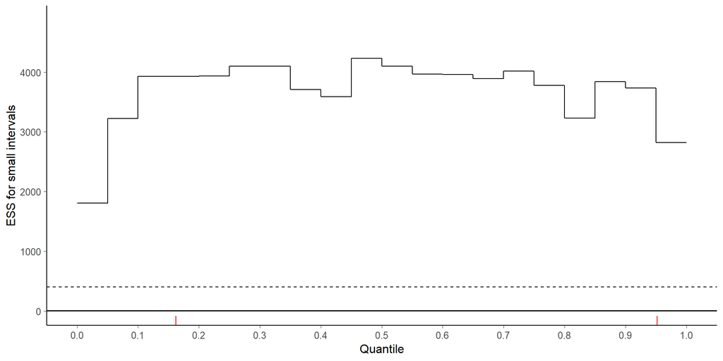

```r
plot_local_ess(fit = fit_ncp, par = "tau", nalpha = 20)
```

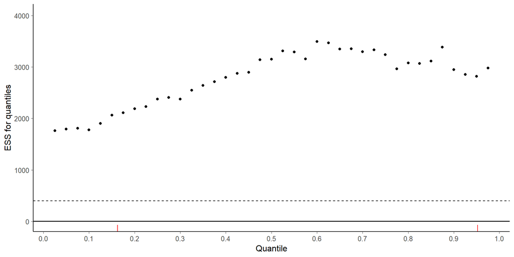

```r
plot_quantile_ess(fit = fit_ncp, par = "tau", nalpha = 40)
```

Overall, the non-centered parameterization looks good even for the default settings of `adapt_delta`, and increasing it to 0.95 gets rid of the last remaining problems. This stands in sharp contrast to what we observed for the centered parameterization, where increasing `adapt_delta` didn’t help at all. Actually, this is something we observe quite often: A suboptimal parameterization can cause problems that are not simply solved by tuning the sampler. Instead, we have to adjust our model to achieve trustworthy inference.

## Appendix G: Dynamic HMC and effective sample size

We have already seen that the effective sample size of dynamic HMC can be higher than with independent draws. The next example illustrates interesting relative efficiency phenomena due to the properties of dynamic HMC algorithms.

We sample from a simple 16-dimensional standard normal model.

```r
writeLines(readLines("normal.stan"))
```

```
data {
  int<lower=1> J;
}
parameters {
  vector[J] x;
}
model {
  x ~ normal(0, 1);
}
```

```r
fit_n <- stan(
  file = 'normal.stan', data = data.frame(J = 16),
  iter = 20000, chains = 4, seed = 483892929, refresh = 0
)
```

```r
samp <- as.array(fit_n)
monitor(samp)
```

```
Inference for the input samples (4 chains: each with iter = 10000; warmup = 0):

          Q5   Q50   Q95  Mean   SD Rhat Bulk_ESS Tail_ESS
x[1]   -1.66  0.00  1.65  0.00 1.00    1    98264    28709
x[2]   -1.64 -0.01  1.64  0.00 1.00    1    95812    29664
x[3]   -1.63  0.00  1.62  0.00 0.99    1    98640    28669
x[4]   -1.65  0.00  1.66  0.01 1.01    1    97302    29166
x[5]   -1.64  0.00  1.63  0.00 1.00    1   101542    29930
x[6]   -1.65  0.00  1.65  0.00 1.00    1    96292    28376
x[7]   -1.63  0.01  1.63  0.00 0.99    1    96016    29238
x[8]   -1.65 -0.01  1.65  0.00 1.00    1   100375    29893
x[9]   -1.64  0.01  1.65  0.00 1.00    1   101141    28621
x[10]  -1.62 -0.01  1.63  0.00 0.99    1   103126    29411
x[11]  -1.65  0.01  1.66  0.00 1.00    1    95886    28488
x[12]  -1.62  0.00  1.63  0.01 0.99    1    98433    29228
x[13]  -1.62  0.01  1.65  0.00 0.99    1    98181    27421
x[14]  -1.63  0.00  1.63  0.00 0.99    1    97313    27507
x[15]  -1.63  0.01  1.64  0.01 0.99    1    95223    29139
x[16]  -1.66  0.00  1.65  0.00 1.01    1    99980    29639
lp__  -13.00 -7.66 -3.92 -7.95 2.79    1    14489    19627

For each parameter, Bulk_ESS and Tail_ESS are crude measures of
effective sample size for bulk and tail quantities respectively (good values is
ESS > 400), and Rhat is the potential scale reduction factor on rank normalized
split chains (at convergence, Rhat = 1).
```

```r
res <- monitor_extra(samp)
print(res)
```

```
Inference for the input samples (4 chains: each with iter = 10000; warmup = 0):

       mean se_mean   sd     Q5   Q50   Q95   seff reff  sseff  zseff zsseff zsreff Rhat sRhat
x[1]   0.00    0.00 1.00  -1.66  0.00  1.65  97846 2.45  98426  97687  98264   2.46    1     1
x[2]   0.00    0.00 1.00  -1.64 -0.01  1.64  95437 2.39  95717  95531  95812   2.40    1     1
x[3]   0.00    0.00 0.99  -1.63  0.00  1.62  98375 2.46  98703  98313  98640   2.47    1     1
x[4]   0.01    0.00 1.01  -1.65  0.00  1.66  96642 2.42  97290  96654  97302   2.43    1     1
x[5]   0.00    0.00 1.00  -1.64  0.00  1.63 101317 2.53 101514 101344 101542   2.54    1     1
x[6]   0.00    0.00 1.00  -1.65  0.00  1.65  96011 2.40  96299  96003  96292   2.41    1     1
x[7]   0.00    0.00 0.99  -1.63  0.01  1.63  95558 2.39  96082  95492  96016   2.40    1     1
x[8]   0.00    0.00 1.00  -1.65 -0.01  1.65  99937 2.50 100392  99920 100375   2.51    1     1
x[9]   0.00    0.00 1.00  -1.64  0.01  1.65 100824 2.52 101134 100831 101141   2.53    1     1
x[10]  0.00    0.00 0.99  -1.62 -0.01  1.63 102178 2.55 102983 102317 103126   2.58    1     1
x[11]  0.00    0.00 1.00  -1.65  0.01  1.66  95226 2.38  95863  95250  95886   2.40    1     1
x[12]  0.01    0.00 0.99  -1.62  0.00  1.63  97828 2.45  98357  97903  98433   2.46    1     1
x[13]  0.00    0.00 0.99  -1.62  0.01  1.65  97666 2.44  98166  97682  98181   2.45    1     1
x[14]  0.00    0.00 0.99  -1.63  0.00  1.63  96805 2.42  97327  96792  97313   2.43    1     1
x[15]  0.01    0.00 0.99  -1.63  0.01  1.64  94911 2.37  95185  94950  95223   2.38    1     1
x[16]  0.00    0.00 1.01  -1.66  0.00  1.65  99541 2.49 100111  99413  99980   2.50    1     1
lp__  -7.95    0.02 2.79 -13.00 -7.66 -3.92  14922 0.37  14934  14480  14489   0.36    1     1
      zRhat zsRhat zfsRhat zfsseff zfsreff tailseff tailreff medsseff medsreff madsseff madsreff
x[1]      1      1       1   16450    0.41    28709     0.72    82432     2.06    19205     0.48
x[2]      1      1       1   16462    0.41    29664     0.74    75494     1.89    19208     0.48
x[3]      1      1       1   16152    0.40    28669     0.72    78630     1.97    18732     0.47
x[4]      1      1       1   16075    0.40    29166     0.73    81148     2.03    19079     0.48
x[5]      1      1       1   16785    0.42    29930     0.75    79953     2.00    20116     0.50
x[6]      1      1       1   16578    0.41    28376     0.71    79018     1.98    19626     0.49
x[7]      1      1       1   17109    0.43    29238     0.73    81690     2.04    19543     0.49
x[8]      1      1       1   16400    0.41    29893     0.75    79263     1.98    18828     0.47
x[9]      1      1       1   15890    0.40    28621     0.72    81119     2.03    18683     0.47
x[10]     1      1       1   16460    0.41    29411     0.74    76948     1.92    19242     0.48
x[11]     1      1       1   15969    0.40    28488     0.71    79164     1.98    18329     0.46
x[12]     1      1       1   15294    0.38    29228     0.73    81841     2.05    18720     0.47
x[13]     1      1       1   15370    0.38    27421     0.69    80615     2.02    18210     0.46
x[14]     1      1       1   16452    0.41    27507     0.69    77592     1.94    19050     0.48
x[15]     1      1       1   16651    0.42    29139     0.73    80406     2.01    19622     0.49
x[16]     1      1       1   16395    0.41    29639     0.74    82347     2.06    18845     0.47
lp__      1      1       1   21484    0.54    19627     0.49    17074     0.43    23603     0.59
```

The Bulk-ESS for all $x$ is larger than 9.522310^{4}. However tail-ESS for all $x$ is less than 2.99300310^{4}. Further, bulk-ESS for `lp__` is only 1.448910^{4}.  
If we take a look at all the Stan examples in this notebook, we see that the bulk-ESS for `lp__` is always below 0.5. This is because `lp__` correlates strongly with the total energy in HMC, which is sampled using a random walk proposal once per iteration. Thus, it’s likely that `lp__` has some random walk behavior, as well, leading to autocorrelation and a small relative efficiency. At the same time, adaptive HMC can create antithetic Markov chains which have negative auto-correlations at odd lags. This results in a bulk-ESS greater than S for some parameters.

Let’s check the effective sample size in different parts of the posterior by computing the effective sample size for small interval estimates for `x[1]`.

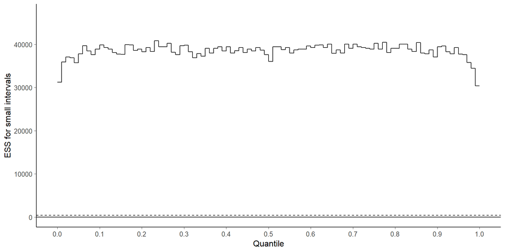

```r
plot_local_ess(fit_n, par = 1, nalpha = 100)
```

The effective sample size for probability estimate for a small interval is close to 1 with a slight drop in the tails. This is a good result, but far from the effective sample size for the bulk, mean, and median estimates. Let’s check the effective sample size for quantiles.

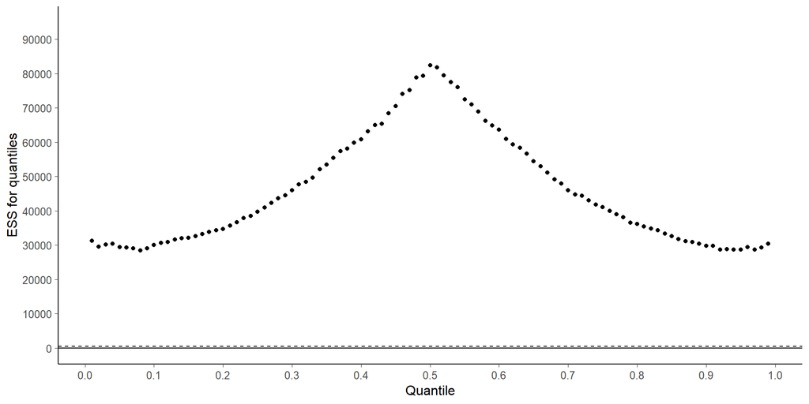

```r
plot_quantile_ess(fit = fit_n, par = 1, nalpha = 100)
```

Central quantile estimates have higher effective sample size than tail quantile estimates.

The total energy of HMC should affect how far in the tails a chain in one iteration can go. Fat tails of the target have high energy, and thus only chains with high total energy can reach there. This will suggest that the random walk in total energy would cause random walk in the variance of $x$. Let’s check the second moment of $x$.

```r
samp_x2 <- as.array(fit_n, pars = "x")^2
monitor(samp_x2)
```

```
Inference for the input samples (4 chains: each with iter = 10000; warmup = 0):

      Q5  Q50  Q95 Mean   SD Rhat Bulk_ESS Tail_ESS
x[1]   0 0.46 3.85 1.01 1.44    1    16443    18225
x[2]   0 0.44 3.80 0.99 1.42    1    16492    19392
x[3]   0 0.45 3.80 0.98 1.39    1    16148    18342
x[4]   0 0.45 3.95 1.01 1.46    1    16070    18288
x[5]   0 0.45 3.86 1.00 1.42    1    16785    18672
x[6]   0 0.45 3.91 1.00 1.42    1    16572    17525
x[7]   0 0.45 3.74 0.99 1.39    1    17097    19120
x[8]   0 0.46 3.80 1.00 1.42    1    16397    18152
x[9]   0 0.45 3.81 1.00 1.41    1    15922    18049
x[10]  0 0.44 3.73 0.98 1.39    1    16461    18098
x[11]  0 0.46 3.85 1.00 1.41    1    16008    19463
x[12]  0 0.45 3.75 0.99 1.41    1    15368    17674
x[13]  0 0.44 3.83 0.98 1.38    1    15371    16755
x[14]  0 0.45 3.75 0.98 1.37    1    16461    17715
x[15]  0 0.45 3.77 0.98 1.38    1    16655    19241
x[16]  0 0.47 3.86 1.01 1.41    1    16400    19741

For each parameter, Bulk_ESS and Tail_ESS are crude measures of
effective sample size for bulk and tail quantities respectively (good values is
ESS > 400), and Rhat is the potential scale reduction factor on rank normalized
split chains (at convergence, Rhat = 1).
```

```r
res <- monitor_extra(samp_x2)
print(res)
```

```
Inference for the input samples (4 chains: each with iter = 10000; warmup = 0):

      mean se_mean   sd Q5  Q50  Q95  seff reff sseff zseff zsseff zsreff Rhat sRhat zRhat zsRhat
x[1]  1.01    0.01 1.44  0 0.46 3.85 14657 0.37 14664 16440  16443   0.41    1     1     1      1
x[2]  0.99    0.01 1.42  0 0.44 3.80 15511 0.39 15518 16488  16492   0.41    1     1     1      1
x[3]  0.98    0.01 1.39  0 0.45 3.80 14684 0.37 14703 16133  16148   0.40    1     1     1      1
x[4]  1.01    0.01 1.46  0 0.45 3.95 14510 0.36 14518 16039  16070   0.40    1     1     1      1
x[5]  1.00    0.01 1.42  0 0.45 3.86 15017 0.38 15029 16766  16785   0.42    1     1     1      1
x[6]  1.00    0.01 1.42  0 0.45 3.91 14368 0.36 14380 16547  16572   0.41    1     1     1      1
x[7]  0.99    0.01 1.39  0 0.45 3.74 15464 0.39 15488 17080  17097   0.43    1     1     1      1
x[8]  1.00    0.01 1.42  0 0.46 3.80 14773 0.37 14766 16397  16397   0.41    1     1     1      1
x[9]  1.00    0.01 1.41  0 0.45 3.81 13439 0.34 13467 15910  15922   0.40    1     1     1      1
x[10] 0.98    0.01 1.39  0 0.44 3.73 14654 0.37 14672 16430  16461   0.41    1     1     1      1
x[11] 1.00    0.01 1.41  0 0.46 3.85 15068 0.38 15098 15997  16008   0.40    1     1     1      1
x[12] 0.99    0.01 1.41  0 0.45 3.75 14215 0.36 14221 15342  15368   0.38    1     1     1      1
x[13] 0.98    0.01 1.38  0 0.44 3.83 13548 0.34 13547 15368  15371   0.38    1     1     1      1
x[14] 0.98    0.01 1.37  0 0.45 3.75 14547 0.36 14565 16418  16461   0.41    1     1     1      1
x[15] 0.98    0.01 1.38  0 0.45 3.77 15417 0.39 15414 16652  16655   0.42    1     1     1      1
x[16] 1.01    0.01 1.41  0 0.47 3.86 15551 0.39 15561 16390  16400   0.41    1     1     1      1
      zfsRhat zfsseff zfsreff tailseff tailreff medsseff medsreff madsseff madsreff
x[1]        1   18445    0.46    18225     0.46    19172     0.48    23268     0.58
x[2]        1   19699    0.49    19392     0.48    19309     0.48    24908     0.62
x[3]        1   18532    0.46    18342     0.46    18694     0.47    23865     0.60
x[4]        1   18983    0.47    18288     0.46    19156     0.48    23907     0.60
x[5]        1   19535    0.49    18672     0.47    20102     0.50    25043     0.63
x[6]        1   17535    0.44    17525     0.44    19596     0.49    22613     0.57
x[7]        1   19019    0.48    19120     0.48    19555     0.49    23336     0.58
x[8]        1   18920    0.47    18152     0.45    18816     0.47    24195     0.60
x[9]        1   18386    0.46    18049     0.45    18674     0.47    22198     0.55
x[10]       1   18570    0.46    18098     0.45    19147     0.48    23900     0.60
x[11]       1   19482    0.49    19463     0.49    18393     0.46    24709     0.62
x[12]       1   18691    0.47    17674     0.44    18588     0.46    23963     0.60
x[13]       1   18506    0.46    16755     0.42    18258     0.46    24132     0.60
x[14]       1   18823    0.47    17715     0.44    19062     0.48    23428     0.59
x[15]       1   19633    0.49    19241     0.48    19620     0.49    24476     0.61
x[16]       1   20083    0.50    19741     0.49    18829     0.47    24441     0.61
```

The mean of the bulk-ESS for $x_j^2$ is 1.62906210^{4}, which is quite close to the bulk-ESS for `lp__`. This is not that surprising as the potential energy in normal model is proportional to $\sum_{j=1}^J x_j^2$.

Let’s check the effective sample size in different parts of the posterior by computing the effective sample size for small interval probability estimates for `x[1]^2`.

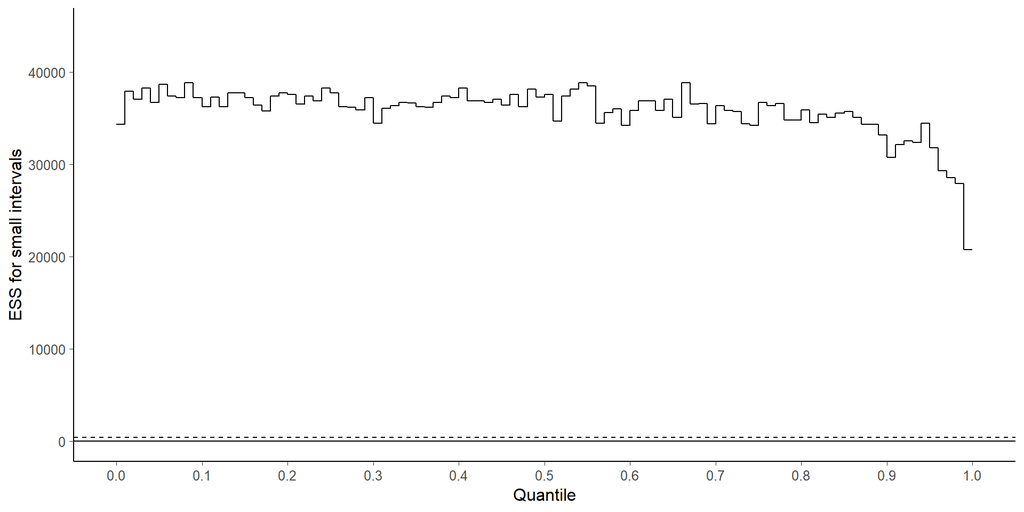

```r
plot_local_ess(fit = samp_x2, par = 1, nalpha = 100)
```

The effective sample size is mostly a bit below 1, but for the right tail of $x_1^2$ the effective sample size drops. This is likely due to only some iterations having high enough total energy to obtain draws from the high energy part of the tail. Let’s check the effective sample size for quantiles.

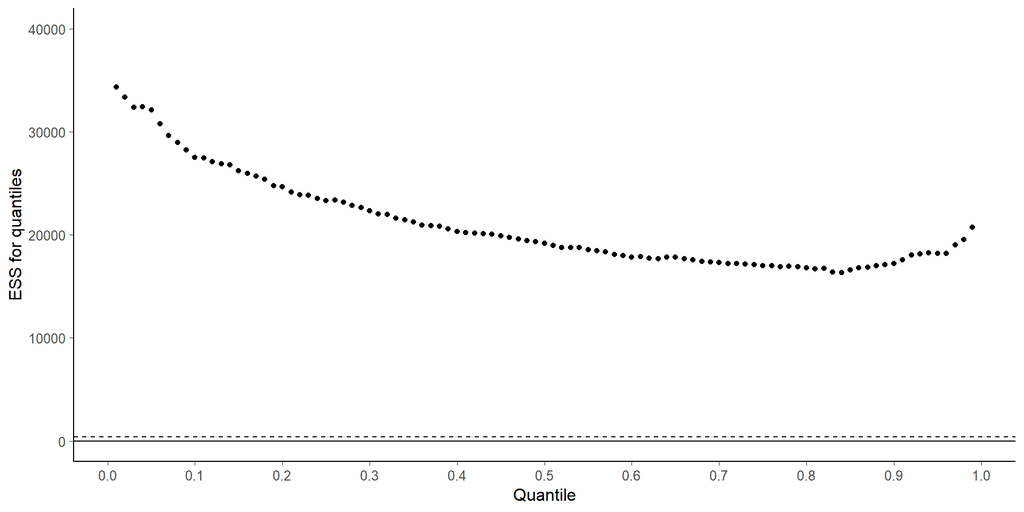

```r
plot_quantile_ess(fit = samp_x2, par = 1, nalpha = 100)
```

We can see the correlation between `lp__` and magnitude of `x[1]` in the following plot.

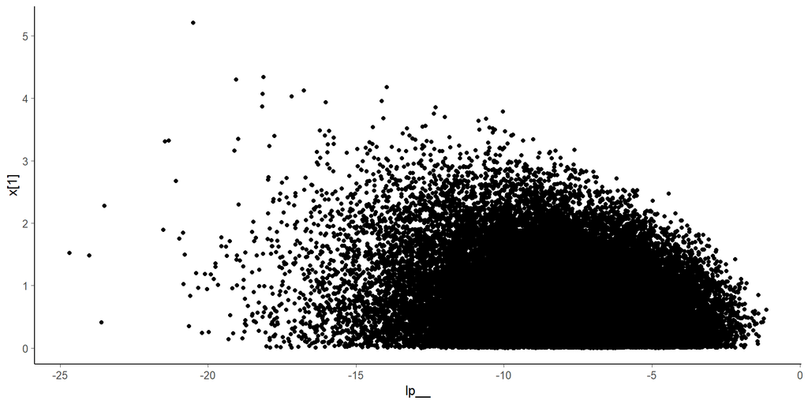

```r
samp <- as.array(fit_n)
qplot(
  as.vector(samp[, , "lp__"]),
  abs(as.vector(samp[, , "x[1]"]))
) +
  labs(x = 'lp__', y = 'x[1]')
```

Low `lp__` values corresponds to high energy and more variation in `x[1]`, and high `lp__` corresponds to low energy and small variation in `x[1]`. Finally $\sum_{j=1}^J x_j^2$ is perfectly correlated with `lp__`.

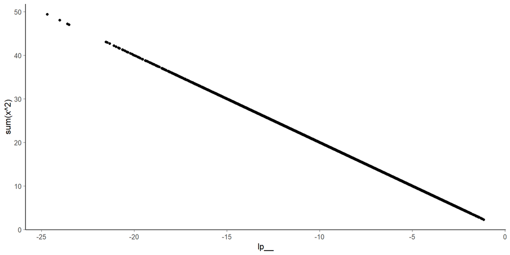

```r
qplot(
  as.vector(samp[, , "lp__"]),
  as.vector(apply(samp[, , 1:16]^2, 1:2, sum))
) +
  labs(x = 'lp__', y = 'sum(x^2)')
```

This shows that even if we get high effective sample size estimates for central quantities (like mean or median), it is important to look at the relative efficiency of scale and tail quantities, as well. The effective sample size of `lp__` can also indicate problems of sampling in the tails.

# Original Computing Environment

```r
makevars <- file.path(Sys.getenv("HOME"), ".R/Makevars")
if (file.exists(makevars)) {
  writeLines(readLines(makevars))
}
```

```
CXX14FLAGS=-O3 -Wno-unused-variable -Wno-unused-function
CXX14 = $(BINPREF)g++ -m$(WIN) -std=c++1y
CXX11FLAGS=-O3 -Wno-unused-variable -Wno-unused-function
```